# Alpine Term

Alpine Term (Alpine Linux Terminal) is a virtual machine running the [Alpine Linux](https://alpinelinux.org) — a security-oriented, lightweight Linux distribution based on musl libc and busybox.

The application is built on top of these 2 core components:

- [QEMU](https://qemu.org) — hardware emulator and virtualizer. Used to emulate x86_64 hardware on which Alpine Linux is running.
- Terminal emulator — a heavily modded version of [Termux](https://github.com/termux), terminal emulator for Android OS. Used for interacting with the virtual machine and operating system.

Application design is minimalistic. You will not find here any overweight functionality. Only the bare minimum of what is needed for interacting with the virtual machine.

## User Guide

Table of contents:

- User interface
  - Terminal
  - Context menu
  - Navigation drawer
  - Notification
  - Extra keys row
  - Text input field
- Keyboard
  - Touch keyboard shortcuts
  - Hardware keyboard shortcuts
- Getting started
  - QEMU monitor
  - Shell
  - Using custom disk images
  - Sharing files between host and VM
  - Shutting down the VM

### User interface

#### Terminal

The application emulates a subset of the X Window System (xterm) terminal with TrueColor support. Its capabilities should be enough for most of the available command line programs.

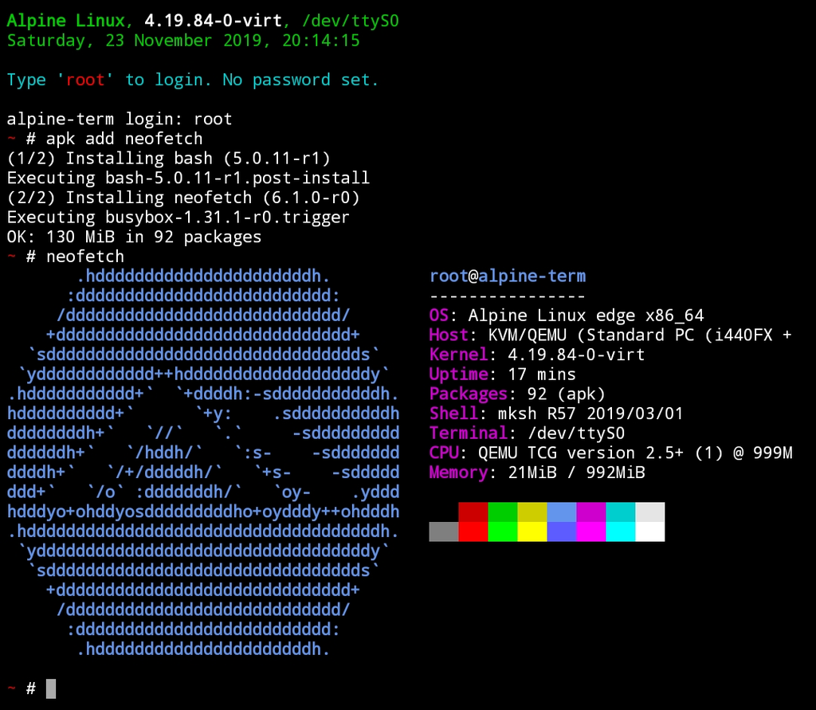

As a connection to the virtual machine is done over serial line, a proper terminal window handshake is not possible. As a result, the virtual machine is not aware of the current state of the terminal emulator. If there is a window size mismatch between terminal emulator and virtual machine, you may observe visual glitches such as displaced or disappeared text when using certain programs.

Use utility ‘resize’ to make sure that the console size matches the size of the screen. If the terminal was messed up, use the utility ‘reset’ which will clean screen and reset the terminal to initial state.

The terminal is sensitive to taps and gestures. For example, pinch-zooming will change the font size and short tap will act as a mouse click. Long tap will toggle a text selection and the context menu. By swiping rightwards, a navigation drawer will be revealed.

#### Context menu

The context menu can be shown by long pressing anywhere on the terminal. It provides menu entries for:

- Opening VNC connection. Available only if [RealVNC Viewer](https://play.google.com/store/apps/details?id=com.realvnc.viewer.android) is installed.
- Copying or pasting text from clipboard.
- Showing this help page.
- Opening URL selector dialog.
- Sharing text from the terminal to other apps.
- Resetting the terminal state if it got messed up.
- Changing a color scheme of the terminal.
- Check box to control whether bell characters should be ignored.

#### Navigation drawer

The navigation drawer is revealed by swiping inwards from the left part of screen.

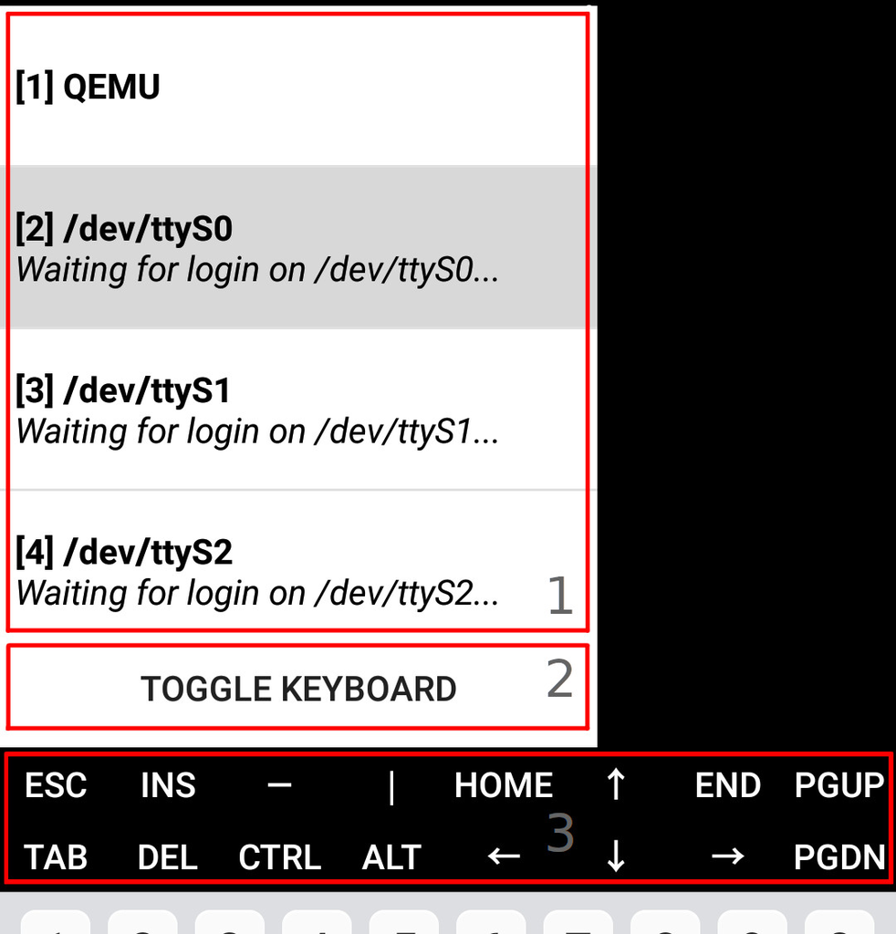

#### Notification

While Alpine Term is running, it displays a notification which can be expanded by a pinch-zooming or a single-finger glide gestures to expose the action for toggling wake lock to prevent device’s CPU going into sleep mode.

[figure not shown]

Clicking on the notification will open the current terminal session.

#### Extra keys row

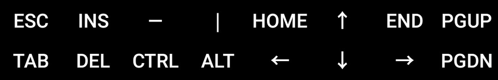

Alpine Term provides a row, which contains some keys frequently used to interact with the command line. It can be toggled by either a long press on the keyboard button located on the drawer or by **Volume Up+Q** and **Volume Up+K** key combinations.

Swiping upwards certain keys will expose the alternate ones. Particularly:

- `-` will show a key for `_`
- `|` will show a key for `&`

Swiping the extra keys row leftwards will reveal the text input field.

#### Text input field

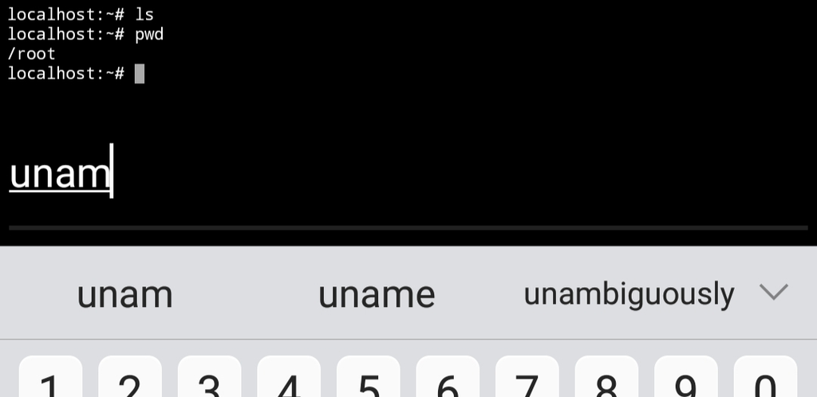

The terminal does not support the advanced features of the touch keyboards like a predictive input or swipe typing. As a workaround, the application provides a special text input field where all these features work correctly.

### Keyboard

#### Touch keyboard shortcuts

**Volume Down** button emulates **Ctrl** key which can be combined with others to request a special action from command line tools. Common key combinations are:

- **Ctrl+A** → Move cursor to the beginning of line
- **Ctrl+C** → Interrupt the current process with SIGINT
- **Ctrl+D** → Send end-of-file to the standard input
- **Ctrl+E** → Move cursor to the end of line
- **Ctrl+K** → Delete text from cursor to the end of line
- **Ctrl+L** → Clear the terminal
- **Ctrl+Z** → Suspend the current process with SIGTSTP

**Volume Up** key is used to produce certain input on the following combinations:

- **Volume Up+.** → Ctrl+\ (SIGQUIT)
- **Volume Up+1** → F1 (and **Volume Up+2** → F2, etc)
- **Volume Up+0** → F10
- **Volume Up+A** → Left arrow key
- **Volume Up+B** → Alt+B, back a word (if using readline)
- **Volume Up+D** → Right arrow key
- **Volume Up+E** → Escape key
- **Volume Up+F** → Alt+F, forward a word (if using readline)
- **Volume Up+H** → ~ (the tilde character)
- **Volume Up+K** → Alias for **Volume Up+Q**
- **Volume Up+L** → | (the pipe character)
- **Volume Up+N** → Page Down
- **Volume Up+P** → Page Up
- **Volume Up+Q** → Toggle extra keys row
- **Volume Up+S** → Down arrow key
- **Volume Up+T** → Tab key
- **Volume Up+U** → _ (the underscore character)
- **Volume Up+V** → Show the volume control
- **Volume Up+W** → Up arrow key
- **Volume Up+X** → Alt+X

Note that **Volume Up** does not represent an **Alt** key even though it is able to emulate some its combinations.

#### Hardware keyboard shortcuts

These keys in combination with **Ctrl+Alt** will trigger certain actions of Alpine Term when using a hardware keyboard:

- **+/-** → Adjust text size
- **1-5** → Go to the session with specified number
- **M** → Show the context menu
- **N** → Switch to the next session
- **P** → Switch to the previous session
- **U** → Open URL selector
- **V** → Paste clipboard
- **Left arrow** → Close drawer
- **Right arrow** → Open drawer
- **Down arrow** → Alias for **N**
- **Up arrow** → Alias for **P**

### Getting started

#### QEMU monitor

QEMU monitor is instrument for controlling the state of the virtual machine. Its console can be accessed through the first tab on the navigation drawer.

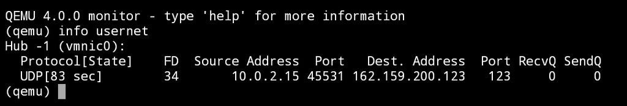

##### List of common monitor commands

| Command | Description |
| --- | --- |
| `help` | Show a full list of available commands. Not all of them are applicable to Alpine Term QEMU instance. |
| `help <command>` | Show help for a specific command. |
| `stop` | Pause emulation. |
| `cont` | Resume emulation. |
| `quit` | Terminate QEMU instance. |
| `sendkey <key>` | Send key (combination) to the virtual machine. For example: ‘ctrl-alt-delete’. |
| `system_powerdown` | Send ACPI request to the operating system to shut down. |
| `system_reset` | Reset the system (reboot). |
| `savevm <name>` | Save a VM snapshot with the specified name. Unmount /mnt/share before using this command. |
| `loadvm <name>` | Load a VM snapshot with the specified name. |
| `delvm <name>` | Delete a VM snapshot with the specified name. |
| `set_link vmnic0 off` | Disable network access. |
| `set_link vmnic0 on` | Enable network access. |
| `hostfwd_add tcp::10022-:22` | Redirect TCP connections from 0.0.0.0:10022 on host to guest port 22. |
| `hostfwd_remove tcp::10022` | Remove port forwarding for 0.0.0.0:10022. |
| `nbd_server_add [-w] <dev id> [name]` | Export a block device with specified ID over NBD. Optionally enable write access (-w) and assign a name. |
| `nbd_server_remove [-f] <name>` | Remove NBD export with the specified name. |
| `nbd_server_start 0.0.0.0:8500` | Start the NBD server listening on 0.0.0.0:8500. |
| `nbd_server_stop` | Stop the NBD server. |
| `screendump <file.ppm>` | Create a PPM screenshot of the display and save to the specified file. |
| `change vnc 127.0.0.1:1` | Start the VNC server on 127.0.0.1:5901. |
| `change vnc 127.0.0.1:1,password` | Start the VNC server on 127.0.0.1:5901 with password authentication. |
| `change vnc none` | Stop the VNC server. |
| `change vnc password` | Set the VNC password. |
| `dump-guest-memory <file>` | Dump memory of the virtual machine into file. |
| `gdbserver tcp::4444` | Start the GDB server listening on TCP 0.0.0.0:4444. |
| `gdbserver none` | Stop the GDB server. |
| `info block` | Show available block devices. |
| `info block-jobs` | Show information about pending jobs for block devices. |
| `info pci` | Show information about PCI devices. |
| `info registers` | Show current values of CPU registers. |
| `info snapshots` | Show available VM snapshots. |
| `info usernet` | Show information about port forwardings and network connections. |
| `info vnc` | Show information about VNC server state. |

QEMU monitor console supports TAB completion. Use this feature to get hints on command arguments.

##### List of device IDs

| Device | ID |
| --- | --- |
| Primary CD-ROM block | `cd0` |
| Primary CD-ROM device | `scsi-cd0` |
| Secondary CD-ROM block | `cd1` |
| Secondary CD-ROM device | `scsi-cd1` |
| Primary HDD block | `hd0` |
| Primary HDD device | `scsi-hd0` |
| Secondary HDD block | `hd1` |
| Secondary HDD device | `scsi-hd1` |
| Network interface card | `vmnic0` |

##### Adding more RAM

QEMU is configured to emulate 4 DIMM slots with support of total RAM up to 16 GiB. By default, it provides a 512 MiB RAM and, if host device has 3 GiB or more, it will use one of the emulated slots to add another 512 MiB. So Alpine Term will provide only 512M/1024M without manual configuration.

You can add more RAM if needed by using the free slots. Here is an example for adding a 1 GiB of memory through QEMU monitor:

```
object_add memory-backend-ram,id=mem1,size=1024M
device_add pc-dimm,id=dimm1,memdev=mem1
```

Do not specify more RAM than the host can provide. In fact, only 50-55% of total allocated RAM by QEMU are safe. Specifying higher values will likely result in Alpine Term being force-closed by the Android OS.

Dynamically limiting of used host RAM is also possible. This can be done through monitor command. See an example of limiting RAM usage to 350M:

```
balloon 350
```

If guest operating system uses less memory than specified value, QEMU will de-allocate host RAM and update visible memory size for the virtual machine. In other cases virtual machine may not release used memory or do that partially.

You can increase the memory allocation by specifying the higher value, however you will not be able use values higher than virtual machine is configured to use. So if QEMU is configured to use 2048M of memory, values beyond the “2048” will not work.

Dynamically changing RAM allocation is implemented through balloon device and requires cooperation from the guest operating system. It must provide a driver for this device. Kernel supplied with Alpine Linux has support for balloon device. Custom operating systems or kernels are not guaranteed to work properly with it.

##### Backing up the HDD image

Use QEMU monitor to back up the operating system image. You can do this by executing the next command:

```
drive_backup -f -c hd0 ./backup.qcow2 qcow2
```

This command will copy the data into the new compressed (option ‘-c’) QCOW2 image ready for reuse. You can continue to use the virtual machine during the backup process. Progress can be tracked by this command:

```
info block-jobs
```

After finishing you can get your image in the Alpine Term private directory on shared storage.

##### Restoring the HDD image

The restoring operation is quite complicated as you cannot have direct access to the runtime directory of Alpine Term. However, you can use trick with the ‘drive_backup’ command to overwrite the original HDD image.

```
# First, reset and stop the virtual machine:
system_reset
stop

# Check the path where the original image is being stored:
info block

# Here it will be assumed that its path is
# /data/user/0/alpine.term/files/run/alpine-linux-hdd.qcow2

# Remove the primary HDD:
drive_del hd0
device_del scsi-hd0

# Now you can temporarily add your backup image as a block device:
drive_add 0 if=none,id=temphd0,format=qcow2,file=./backup.qcow2

# And overwrite the original HDD image:
drive_backup -f -c temphd0 /data/user/0/alpine.term/files/run/alpine-linux-hdd.qcow2 qcow2
```

Wait until job finishes (command ‘info block-jobs’) and then restart Alpine Term.

#### Shell

##### List of common shell commands

| Command | Description |
| --- | --- |
| `apk add <pkg>` | Install the specified package. |
| `apk del <pkg>` | Uninstall the specified package. |
| `apk upgrade` | Upgrade the installed packages. |
| `apk info` | List the installed packages. |
| `cat <file>` | Print content of the specified file. |
| `cd <dir>` | Navigate to the specified directory. |
| `chgrp <group> <path>` | Change the group of the specified file or directory. |
| `chmod <mode> <path>` | Change access mode of the specified file or directory. |
| `chown <ownership> <path>` | Change ownership of the specified file or directory. |
| `cp <src> <dst>` | Copy file from the specified source to destination. |
| `date` | Print the current date and time. |
| `df -h` | Show the current disk space usage. |
| `dmesg` | Print the kernel log. |
| `file <path>` | Detect a type of the specified file. |
| `free -h` | Show RAM usage. |
| `grep <pattern> <file>` | Find occurrences of the specified pattern in a file. |
| `gunzip <file.gz>` | Decompress the given file. |
| `gzip <file>` | Compress the given file. |
| `hostname` | Print the current system host name. |
| `id` | Print the user and group IDs associated with current user. |
| `ifconfig` | Show the information about active network interfaces. |
| `kill -9 <pid>` | Kill the process with specified PID. |
| `ln -s <src> <dest>` | Create a symbolic link between the specified source and destination. |
| `ls` | List files in the current directory. |
| `ls <dir>` | List files in the specified directory. |
| `man <command>` | Open manual for the specified command. |
| `mkdir -p <path>` | Create directory at the specified path. |
| `mv <src> <dst>` | Move file or directory from the specified source to destination. Can be used to rename files. |
| `nano <file.txt>` | Edit specified text file with Nano editor. |
| `netstat -tun` | Show the active network connections. |
| `netstat -tuln` | Show the listening sockets (servers). |
| `poweroff` | Shut down the machine. |
| `ps aux` | Show all system processes. |
| `pwd` | Print the path of the current working directory. |
| `reboot` | Reboot the operating system. |
| `rm -rf <path>` | Delete the specified file or directory. |
| `reset` | Reset the terminal. |
| `resize` | Resize the console. |
| `tar cf file.tar <dir>` | Create a tar archive of the specified directory. |
| `tar xf file.tar` | Extract the specified tar archive. |
| `uname -a` | Show system host name, kernel version and CPU architecture. |
| `wget <url>` | Download file from the specified URL. |

For more details about shell usage and scripting you can read the Advanced Bash-Scripting Guide. Although this guide is for Bash shell, most of the tips apply to other shells as well.

Also read the [Alpine Linux Wiki](https://wiki.alpinelinux.org) for details about administering Alpine systems.

#### Using custom disk images

You can have additional CD-ROM or HDD image. To do so place your ISO or QCOW2 file on shared storage and make sure their names are ‘cdrom.iso’ and ‘hdd.qcow2’ respectively. Note that this way allows you to have only one image of each type.

Another variant how to add a disk image would be the use of the monitor console. Here is an example of how to add a custom CD-ROM image:

```
# Regular way with just ISO file.
drive_add 0 if=none,media=cdrom,id=cd1,file=./mycd.iso

# Or remote image accessible over HTTP:
drive_add 0 if=none,media=cdrom,id=cd1,file=https://example.com/cdrom.iso

# NBD also works:
drive_add 0 if=none,media=cdrom,id=cd1,file=nbd://192.168.1.10:1024/cdrom

# Once block device is added, create a CD-ROM device:
device_add scsi-cd,id=scsi-cd1,drive=cd1
```

#### Sharing files between host and VM

```
/storage/self/primary/Android/data/alpine.term/files
```

**Warning**: if you want to uninstall the Alpine Term, do not forget to move files from the host shared directory to a different place. Otherwise, all its data will be lost.

#### Shutting down the VM

You can shut down the virtual machine and exit application with these ways:

- Executing command ‘quit’ in QEMU monitor for immediate exit. May leave HDD file system in an inconsistent state.
- Executing command ‘system_powerdown’ in QEMU monitor to initiate OS shut down through ACPI.
- Executing command ‘poweroff’ in OS shell.

If application got frozen and does not respond for some reason, you will need to force stop it through Android OS settings.

*Alpine Term by Leonid Pliushch (aka @xeffyr)*